# Introduction to IMPACTaf

Dr. Chris Kypridemos

11 March, 2024

#### How to initialize the model

```r
library(IMPACTaf)

IMPACTncd <- Simulation$new("./inputs/sim_design.yaml")
```

### `country`

- The name of the country used for labeling or loading specific datasets (e.g., “UK” or “Italy”).
- List of countries: “Austria”, “Belgium”, “Cyprus”, “Estonia”, “Finland”, “France”, “Germany”, “Greece”, “Ireland”, “Italy”, “Latvia”, “Lithuania”, “Luxembourg”, “Malta”, “Netherlands”, “Portugal”, “Slovakia”, “Slovenia”, “Spain”, “United Kingdom”
- Update this to reflect the population or setting your simulation represents.

### `n`

- Total number of individuals to simulate in each Monte Carlo iteration.
- Example: `n: 10000` for 10,000 individuals.

### `aggregation`

- Whether the output is aggregated or kept at the individual level.
- Set to `"none"` for individual-level lifecourse data. This should not be changed as we need individual-level data for the transition model.

### `init_year_long`

- The calendar year in which the simulation begins.
- Example: `init_year_long: 2020` means your simulation starts in the year 2020.

### `sim_horizon_max`

- Total number of years to simulate (the length of the time horizon).
- Example: `sim_horizon_max: 30` for a 30-year simulation.

### `ageL`, `ageH`

- Lower and upper bounds for **age inclusion** in the simulated cohort.
- Only individuals within this age range will be included at initialization.
- Example:

  ```yaml
  ageL: 65
  ageH: 100
  ```

In particular, you may need to adjust the `n` and `n_synthpop_aggregation` parameters to create the desired synthetic population size. If you use the same `synthpop_dir` location as in your test run, the new synthpop files will have a different filename and will not overwrite the existing files. However, you may want to delete the existing synthpop files in the folder to save disk space.

1. To run a baseline scenario, run the following chunk of code, which deletes everything inside the existing output and log folders, runs a new baseline scenario from scratch and summarises the results of the simulation.

```r
IMPACTncd$
  del_logs()$
  del_outputs()$
  run(mc = 1:5, multicore = FALSE)$
  export_summaries(multicore = FALSE)
```

In the above, we use the chain syntax using $, which is equivalent to:

```r
IMPACTncd$del_logs()
IMPACTncd$del_outputs()
IMPACTncd$run(mc = 1:5, multicore = FALSE)
IMPACTncd$export_summaries(multicore = FALSE)
```

Finally, the `export_summaries()` generates summary output files from the lifecourse files that are the raw simulation output.

2. After running the code, we will create the folders shown below. The `lifecourse` folder has the same number of files as the number of iterations runs.

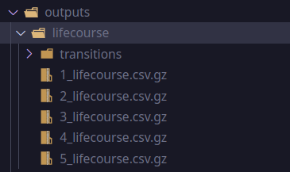

In this example, we specify the `type` to only export a few of the summary outputs to reduce computation time. We have chosen:

- **dis_char** : disease characteristics, e.g. age of onset of condition, mean duration of condition;
- **prvl** : prevalence of each condition;
- **incd** : incidence of each condition;
- **dis_mrtl** : disease-specific mortality;
- **mrtl** : all-cause mortality;
- **allcause_mrtl_by_dis** : all-cause mortality by disease;

If type is not specified, all summary files are exported.

```r
IMPACTncd$
  run(1:n_runs, multicore = FALSE) $
    export_summaries(multicore = FALSE, type = c("dis_char", "prvl",
                     "incd", "dis_mrtl", "mrtl",
                     "allcause_mrtl_by_dis", "cms"))
```